# Naive Bayes

Nik Bear Brown

In this lesson we’ll learn the how to implement Naive Bayes in R.

# Additional packages needed

To run the code you may need additional packages.

- If necessary install the followings packages.

`install.packages("tm");`  
`install.packages("wordcloud");`  
`install.packages("e1071");`  
`install.packages("gmodels");`

```r
library(tm)
```

```r
library(wordcloud)
library(e1071)
library(gmodels)
```

# Data

We will be using the SMS Spam Collection v.1, which is a public set of SMS labeled messages that have been collected for mobile phone spam research. It has one collection composed by 5,574 English, real and non-enconded messages, tagged according being legitimate (ham) or spam.

- from http://www.dt.fee.unicamp.br/~tiago/smsspamcollection/

```r
data_url <- 'http://nikbearbrown.com/YouTube/MachineLearning/M10/sms_spam.csv'
# SMS
sms_data <- read.csv(url(data_url), stringsAsFactors = FALSE)
str(sms_data)
```

```
## 'data.frame':    5559 obs. of  2 variables:
##  $ type: chr  "ham" "ham" "ham" "spam" ...
##  $ text: chr  "Hope you are having a good week. Just checking in" "K..give back my thanks." "Am also doing in cbe only. But have to pay." "complimentary 4 STAR Ibiza Holiday or £10,000 cash needs your URGENT collection. 09066364349 NOW from Landline "| __truncated__ ...
```

```r
# convert spam/ham to factor.
sms_data$type <- factor(sms_data$type)
str(sms_data$type)
```

```
##  Factor w/ 2 levels "ham","spam": 1 1 1 2 2 1 1 1 2 1 ...
```

```r
table(sms_data$type)
```

```
##
##  ham spam
## 4812  747
```

# Naive Bayes

[Naive Bayes classifiers](https://en.wikipedia.org/wiki/Naive_Bayes_classifier) are a family of simple probabilistic classifiers based on applying Bayes’ theorem with strong (naive) independence assumptions between the features. This means that under the above independence assumptions, the conditional distribution over the class variable C is:

$$p(C_k \vert x_1, \dots, x_n) = \frac{1}{Z} p(C_k) \prod_{i=1}^n p(x_i \vert C_k)$$

where the evidence $Z = p(\mathbf{x})$ is a scaling factor dependent only on $x_1, \dots, x_n$, that is, a constant if the values of the feature variables are known.

# Naive Bayes in R

```r
#  build a corpus using the text mining (tm) package
sms_corpus <- Corpus(VectorSource(sms_data$text))
print(sms_corpus)
```

```
## <<SimpleCorpus>>
## Metadata:  corpus specific: 1, document level (indexed): 0
## Content:  documents: 5559
```

```r
inspect(sms_corpus[1:3])
```

```
## <<SimpleCorpus>>
## Metadata:  corpus specific: 1, document level (indexed): 0
## Content:  documents: 3
##
## [1] Hope you are having a good week. Just checking in
## [2] K..give back my thanks.
## [3] Am also doing in cbe only. But have to pay.
```

```r
# clean up the corpus using tm_map()
CleanCorpus <- tm_map(sms_corpus, content_transformer(tolower))
CleanCorpus <- tm_map(CleanCorpus, removeNumbers )
CleanCorpus <- tm_map(CleanCorpus, removeWords, stopwords() )
CleanCorpus <- tm_map(CleanCorpus, removePunctuation )
CleanCorpus <- tm_map(CleanCorpus, stripWhitespace )
inspect(sms_corpus[1:3])
```

```
## <<SimpleCorpus>>
## Metadata:  corpus specific: 1, document level (indexed): 0
## Content:  documents: 3
##
## [1] Hope you are having a good week. Just checking in
## [2] K..give back my thanks.
## [3] Am also doing in cbe only. But have to pay.
```

```r
inspect(CleanCorpus[1:3])
```

[output not shown]

```r
# document-term sparse matrix
sms_dtm <- DocumentTermMatrix(CleanCorpus)
sms_dtm
```

```
## <<DocumentTermMatrix (documents: 5559, terms: 7921)>>
## Non-/sparse entries: 42657/43990182
## Sparsity           : 100%
## Maximal term length: 40
## Weighting          : term frequency (tf)
```

```r
#  training and test datasets
sms_data_train <- sms_data[1:4169, ]
sms_data_test  <- sms_data[4170:5559, ]
sms_dtm_train <- sms_dtm[1:4169, ]
sms_dtm_test  <- sms_dtm[4170:5559, ]
sms_corpus_train <- CleanCorpus[1:4169]
sms_corpus_test  <- CleanCorpus[4170:5559]
# check that the proportion
prop.table(table(sms_data_train$type))
```

```
##
##       ham      spam
## 0.8647158 0.1352842
```

```r
prop.table(table(sms_data_test$type))
```

```
##
##       ham      spam
## 0.8683453 0.1316547
```

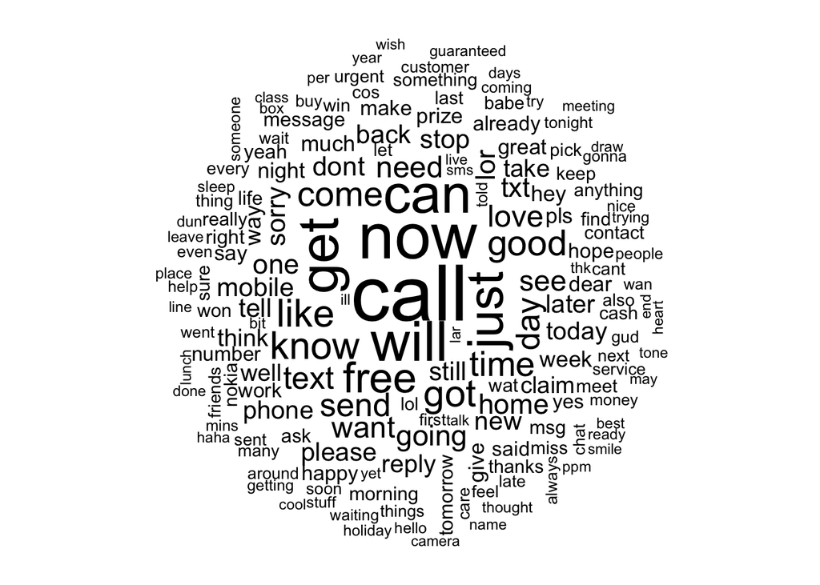

```r
#  word cloud visualization
wordcloud(sms_corpus_train, min.freq = 33, random.order = FALSE)
```

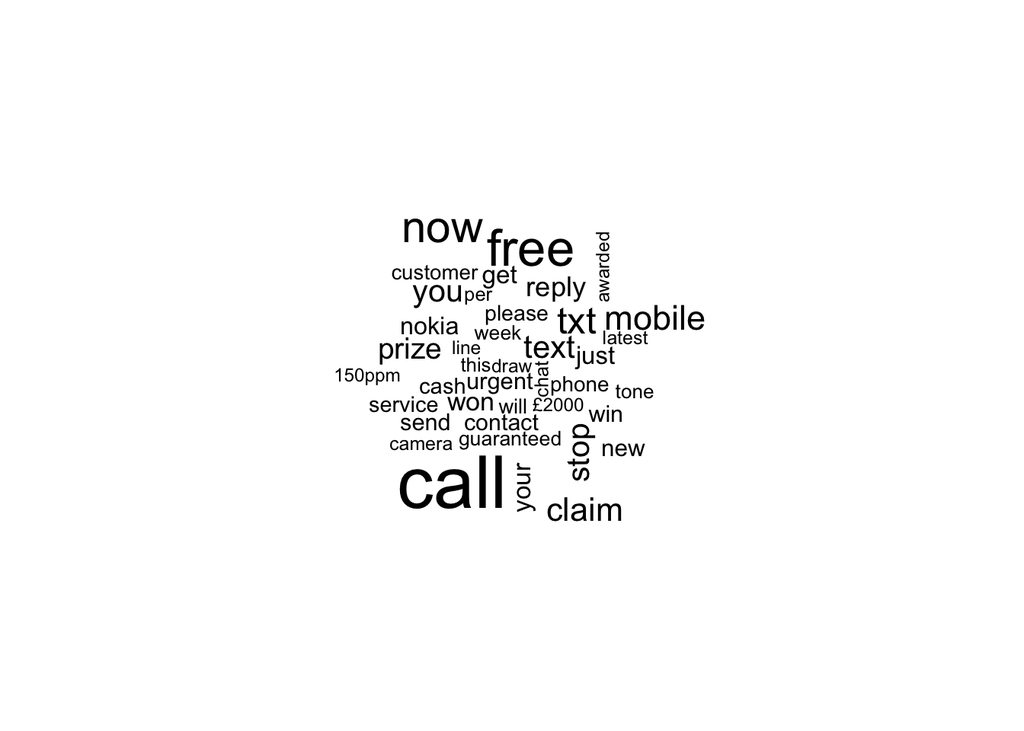

```r
# subset the training data into spam and ham groups
spam <- subset(sms_data_train, type == "spam")
ham  <- subset(sms_data_train, type == "ham")
wordcloud(spam$text, max.words = 40, scale = c(3, 0.5))
```

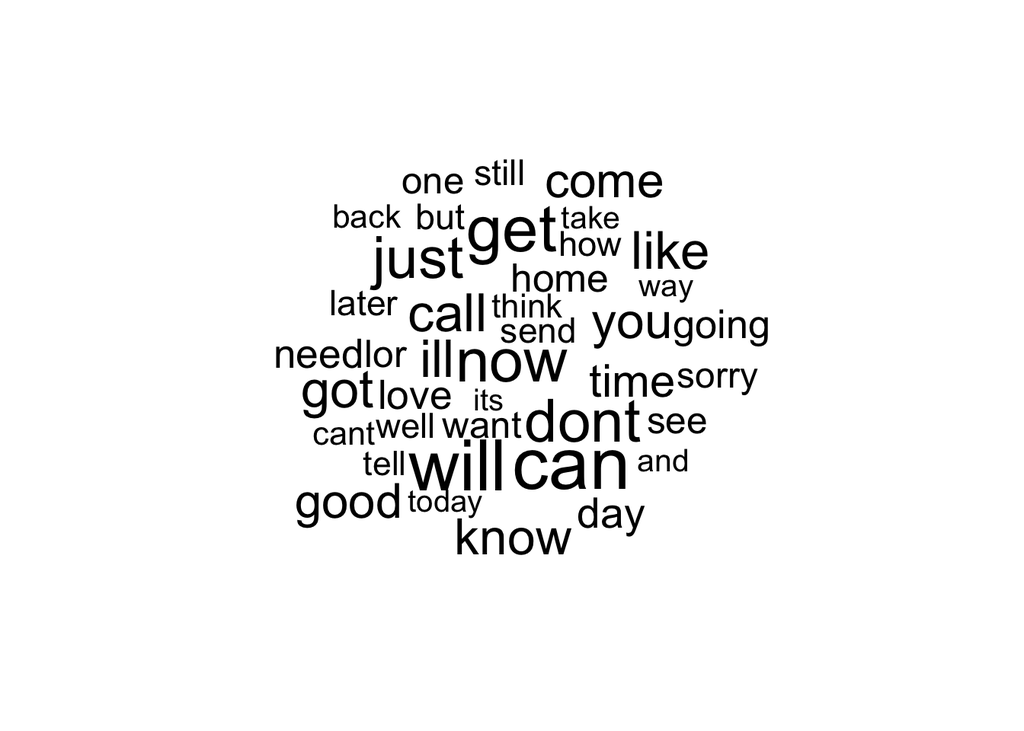

```r
wordcloud(ham$text, max.words = 40, scale = c(3, 0.5))
```

```r
# indicator features for frequent words
findFreqTerms(sms_dtm_train, 5)
```

```
##    [1] "checking"            "good"                "hope"
##    [4] "just"                "week"                "back"
##    [7] "thanks"              "also"                "pay"
##   [10] "cash"                "collection"          "complimentary"
##   [13] "holiday"             "landline"            "lose"
##   [16] "needs"               "now"                 "urgent"
##   [19] "award"               "box"                 "call"
##   [22] "collect"             "dear"                "final"
##   [25] "notice"              "ppm"                 "sae"
##   [28] "tcs"                 "tenerife"            "lar"
##   [31] "later"               "pick"                "much"
##   [34] "ask"                 "father"              "please"
##   [37] "free"                "game"                "mobile"
##   [40] "official"            "play"                "right"
##   [43] "send"                "text"                "room"
```

[output cut: 391 more lines]

```r
sms_dict <- findFreqTerms(sms_dtm_train, 5)
sms_train <- DocumentTermMatrix(sms_corpus_train, list(dictionary = sms_dict))
sms_test  <- DocumentTermMatrix(sms_corpus_test, list(dictionary = sms_dict))
# convert counts to a factor
convert_counts <- function(x) {
  x <- ifelse(x > 0, 1, 0)
  x <- factor(x, levels = c(0, 1), labels = c("No", "Yes"))
}
# apply() convert_counts() to columns of train/test data
sms_train <- apply(sms_train, MARGIN = 2, convert_counts)
sms_test  <- apply(sms_test, MARGIN = 2, convert_counts)
#----------------------------------------------------Training a model on the data --------------------
sms_classifier <- naiveBayes(sms_train, sms_data_train$type)
sms_classifier
```

[output not shown]

[output cut: 6046 more lines]

[output not shown]

```r
#----------------------------------------------     Evaluating model performance --------------------
sms_test_pred <- predict(sms_classifier, sms_test)
CrossTable(sms_test_pred, sms_data_test$type,
           prop.chisq = FALSE, prop.t = FALSE, prop.r = FALSE,
           dnn = c('predicted', 'actual'))
```

```
##
##
##    Cell Contents
## |-------------------------|
## |                       N |
## |           N / Col Total |
## |-------------------------|
##
##
## Total Observations in Table:  1390
##
##
##              | actual
##    predicted |       ham |      spam | Row Total |
## -------------|-----------|-----------|-----------|
##          ham |      1203 |        32 |      1235 |
##              |     0.997 |     0.175 |           |
## -------------|-----------|-----------|-----------|
##         spam |         4 |       151 |       155 |
##              |     0.003 |     0.825 |           |
## -------------|-----------|-----------|-----------|
## Column Total |      1207 |       183 |      1390 |
##              |     0.868 |     0.132 |           |
## -------------|-----------|-----------|-----------|
##
##
```

```r
#---------------------------------------------------Improving model performance ----------------------

sms_classifier2 <- naiveBayes(sms_train, sms_data_train$type, laplace = 1)
sms_test_pred2 <- predict(sms_classifier2, sms_test)
CrossTable(sms_test_pred2, sms_data_test$type,
           prop.chisq = FALSE, prop.t = FALSE, prop.r = FALSE,
           dnn = c('predicted', 'actual'))
```

```
##
##
##    Cell Contents
## |-------------------------|
## |                       N |
## |           N / Col Total |
## |-------------------------|
##
##
## Total Observations in Table:  1390
##
##
##              | actual
##    predicted |       ham |      spam | Row Total |
## -------------|-----------|-----------|-----------|
##          ham |      1204 |        31 |      1235 |
##              |     0.998 |     0.169 |           |
## -------------|-----------|-----------|-----------|
##         spam |         3 |       152 |       155 |
##              |     0.002 |     0.831 |           |
## -------------|-----------|-----------|-----------|
## Column Total |      1207 |       183 |      1390 |
##              |     0.868 |     0.132 |           |
## -------------|-----------|-----------|-----------|
##
##
```

# Resources

- [Data Mining Algorithms In R/Classification/Na?ve Bayes](https://en.wikibooks.org/wiki/Data_Mining_Algorithms_In_R/Classification/Na%C3%AFve_Bayes)
- [Naive Bayes Classifier in r - YouTube](https://www.youtube.com/watch?v=-SeyrC4yZF4)
- [naive Bayes in R - Josh Walters](http://joshwalters.com/2012/11/27/naive-bayes-classification-in-r.html)
- [R: Naive Bayes Classifier](http://ugrad.stat.ubc.ca/R/library/e1071/html/naiveBayes.html)
- [R code: classification with Naive Bayes - Katrin Erk](http://www.katrinerk.com/courses/r-worksheets/r-code-classification-with-naive-bayes)